# exemplar_analysis

1 Measurement Science II; Exemplar Analysis

2 Setting Up Python

3 Quinine Analysis

4 Binding Sites Analysis (Scatchard analysis method)

5 Unfolding Calculations

## Measurement Science II; Exemplar Analysis

## Setting Up Python

The recommended manner to analyse scientific data is using the [Anaconda](https://www.continuum.io/why-anaconda) Scientific Python Distribution, available for free download. When using this it is also suggested that you setup an isolated Python *environment* so that you can control what version of third-party packages you are using. This is acheived in the command prompt as follows;

```
conda create --name mm2 ipython tornado pyzmq numpy matplotlib pandas
```

Next you activate your environment and open this IPython Notebook, with an option to render data plots within the notebook.

```
source activate mm2
cd path/to/notebook
ipython notebook
```

```python
%matplotlib inline
```

Lastly, to use the third-party packages, you must `import` them.

```python
import numpy as np
import matplotlib.pyplot as plt
import matplotlib as mpl
import pandas as pd
mpl.rcParams['axes.grid'] = True
mpl.rcParams['lines.linewidth'] = 1.5
```

Files in analysis folder;

```python
ls
```

```
ANS_BSA_1_conc.dat                Q16_conc.dat*
ANS_binding.jpg                   exemplar_analysis.html
BSA_ANS_TEST1_conc.dat            exemplar_analysis.ipynb
BSA_ANS_TESTING1_conc.dat         mwc14-241116-ANS-var-C1_conc.dat*
BSA_ANS_labgroup.dat              scatchard.jpg
Cheat sheet.docx                  urea_expt_conc.dat
Q13_conc.dat*                     urea_test1_conc.dat
Q14_conc.dat*                     urea_test2_conc.dat
Q15_conc.dat*
```

## Quinine Analysis

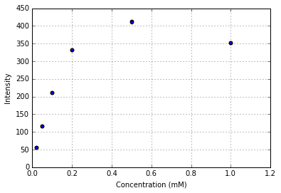

```python
df = pd.read_csv('Q16_conc.dat',sep='\t')
df.rename(columns={'Concentration ':'Concentration (mM)'},inplace=True)
ax = df.plot(x='Concentration (mM)',y=' Intensity ',kind='scatter')
ax.set_xbound(lower=0.0);
```

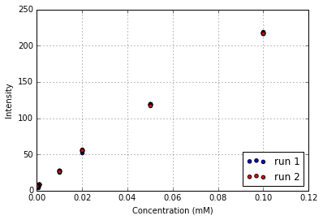

```python
df1 = pd.read_csv('Q14_conc.dat',sep='\t')
df2 = pd.read_csv('Q15_conc.dat',sep='\t')

df1.rename(columns={'Concentration ':'Concentration (mM)'},inplace=True)
df2.rename(columns={'Concentration ':'Concentration (mM)'},inplace=True)

ax = df1.plot(x='Concentration (mM)',y=' Intensity ',kind='scatter',label='run 1')
df2.plot(x='Concentration (mM)',y=' Intensity ',kind='scatter',ax=ax,color='red',label='run 2')
ax.legend(loc='lower right')
ax.set_xbound(lower=0.0);
ax.set_ybound(lower=0.0);
```

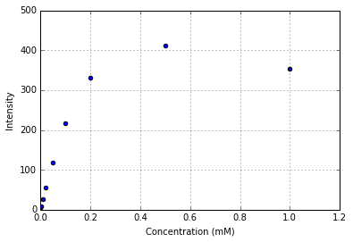

```python
df3 = pd.concat([df, df1,df2])
df4 = df3.groupby('Concentration (mM)').mean().reset_index()
ax = df4.plot(x='Concentration (mM)',y=' Intensity ',kind='scatter')
ax.set_xbound(lower=0.0);
ax.set_ybound(lower=0.0);
```

## Binding Sites Analysis (Scatchard analysis method)

Using http://onlinelibrary.wiley.com/doi/10.1002/bmb.2002.494030050089/full for comparison. Binding of ANS to 10 μM BSA (λexc = 370 nm, λem = 475 nm), both native (▪) and H2O2-oxidized BSA (○).

```python
ls
```

```
ANS_BSA_1_conc.dat                Q16_conc.dat*
ANS_binding.jpg                   exemplar_analysis.html
BSA_ANS_TEST1_conc.dat            exemplar_analysis.ipynb
BSA_ANS_TESTING1_conc.dat         mwc14-241116-ANS-var-C1_conc.dat*
BSA_ANS_labgroup.dat              scatchard.jpg
Cheat sheet.docx                  urea_expt_conc.dat
Q13_conc.dat*                     urea_test1_conc.dat
Q14_conc.dat*                     urea_test2_conc.dat
Q15_conc.dat*
```

Binding of ANS to 10 μM BSA (λexc = 370 nm, λem = 475 nm), both native (▪) and H2O2-oxidized BSA (○).

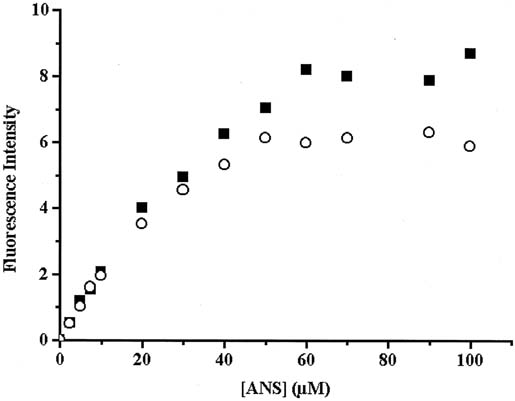

```python
from IPython.display import Image
Image(width=300, filename='ANS_binding.jpg')
```

Scatchard plot for the binding of ANS to native (▪) and H2O2-oxidized BSA (○).

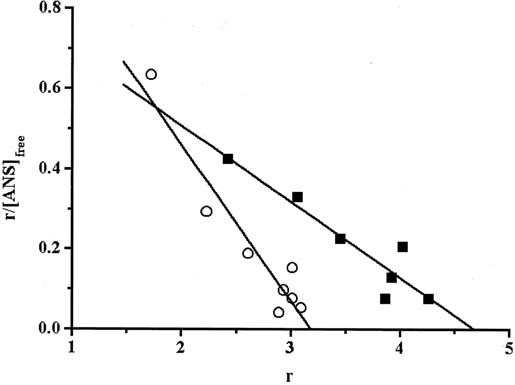

```python
Image(width=300,filename='scatchard.jpg')
```

$F = B.[ANS]_{bound}$, s.t. B is the proportionality constant. Therefore, assuming that all ANS is bound below 10 μM, B = 0.2

$[ANS]_{free} = [ANS]_{Total} - [ANS]_{bound} = [ANS]_{Total} - F/B = [ANS]_{Total} - 5F$

```python
exp_data_file = 'BSA_ANS_labgroup.dat'
import pandas as pd
df = pd.read_csv(exp_data_file)
df.head()
```

|  | Concentration | Intensity | Mean V | STD V | Unnamed: 4 | Unnamed: 5 | Unnamed: 6 | Unnamed: 7 | Unnamed: 8 | Unnamed: 9 |
| --- | --- | --- | --- | --- | --- | --- | --- | --- | --- | --- |
| 0 | 0 | 5.736 | 5.736 | 0.849885 | NaN | NaN | NaN | NaN | NaN | NaN |
| 1 | 20 | 55.008 | 55.008 | 2.627534 | NaN | NaN | NaN | NaN | NaN | NaN |
| 2 | 40 | 108.000 | 108.000 | 0.000000 | NaN | NaN | NaN | NaN | NaN | NaN |
| 3 | 60 | 137.100 | 137.100 | 3.002999 | NaN | NaN | NaN | NaN | NaN | NaN |
| 4 | 80 | 173.856 | 173.856 | 0.641299 | NaN | NaN | NaN | NaN | NaN | NaN |

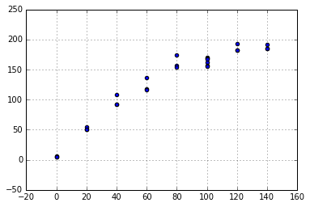

```python
plt.scatter(df.Concentration,df.Intensity)
```

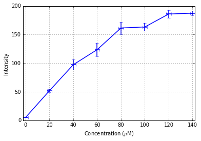

```python
mean = df.groupby('Concentration').mean()
std = df.groupby('Concentration').std()
ax = mean.Intensity.plot(yerr=std.Intensity, xerr=2)
ax.set_xlabel('Concentration ($\mu$M)')
ax.set_ylabel('Intensity')
# concentrations in uM, BSA conc is 20uM
```

$F = K.[ANS]_{bound}$, s.t. K is the proportionality constant. Therefore, assuming that all ANS is bound below 20 uM

```python
mean = df.groupby('Concentration').mean()
BSA_conc = 20
K = mean.loc[BSA_conc].Intensity / BSA_conc
K
```

```
2.5962000000000001
```

$[ANS]_{free} = [ANS]_{Total} - [ANS]_{bound} = [ANS]_{Total} - F/K = [ANS]_{Total} - (1/K).F$

```
kD=9.162 and sites=4.226
```

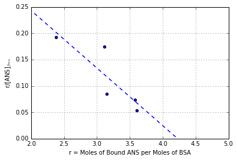

```python
mean['Free'] = mean.index - (1/K) * mean.Intensity
mean['Bound'] = (1/K) * mean.Intensity
mean['r'] = mean.Bound/BSA_conc
mean['r/ANS_free'] = mean.r / mean.Free
plt.scatter(mean['r'],mean['r/ANS_free'])
plt.xlabel('r = Moles of Bound ANS per Moles of BSA')
plt.ylabel('r/[ANS]$_{free}$')
plt.ylim(0,0.25)
plt.xlim(2,5)

# when fitting ignore region where ANS_free is 0 (0-20)
slope, y_intercept = np.polyfit(mean['r'][-5:],mean['r/ANS_free'][-5:],1)
r_array = np.arange(1,6)
plt.plot(r_array,y_intercept+slope*r_array, 'b--')

print('kD={0:.3f} and sites={1:.3f}'.format(-1/slope, -y_intercept/slope))
```

## Unfolding Calculations

```python
cat urea_test1_conc.dat
```

[output not shown]

```python
def read_conc_intens_data(data_files, conc_conversion=1.0):
    """ conc_conversion is conversion required to for Molar units"""
    data_concs = []
    data_intens = []
    for f in data_files:
        d = np.loadtxt(f, skiprows=2)
        x, y = d[:,0]*conc_conversion, d[:,1]
        if data_concs == []:
            data_concs = x
        else:
            # check all files have same concentration set
            if not (data_concs == x).all():
                raise IOError('{0} has a different concentration set'.format(f))
        data_intens.append(y)
    return data_concs, np.array(data_intens)
```

```python
read_conc_intens_data(['urea_test1_conc.dat'], conc_conversion=1e-3)
```

```
(array([  0.,   1.,   2.,   3.,   4.,   5.,   6.,   7.,   8.,   9.,  10.,
         11.,  12.]),
 array([[ 309.   ,  327.228,  336.816,  303.   ,  315.   ,  309.   ,
          309.   ,  255.   ,  190.908,  108.   ,   73.956,   57.66 ,
           56.844]]))
```

Generalised for any number of experimental repeats

```python
bind_data_files = ['urea_test1_conc.dat', 'urea_test2_conc.dat']
bind_data_concs, bind_data_intens = read_conc_intens_data(bind_data_files, conc_conversion=1e-3)
print bind_data_concs
print bind_data_intens
```

```
[  0.   1.   2.   3.   4.   5.   6.   7.   8.   9.  10.  11.  12.]
[[ 309.     327.228  336.816  303.     315.     309.     309.     255.
   190.908  108.      73.956   57.66    56.844]
 [ 273.828  246.924  302.784  228.48   281.94   269.784  306.696  255.696
   179.472   87.108   51.      35.484   33.888]]
```

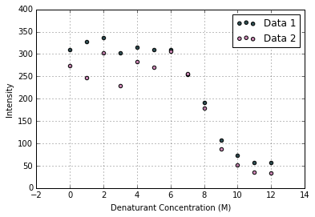

```python
for i, intens in enumerate(bind_data_intens):
    plt.scatter(bind_data_concs, intens, c=np.random.rand(3,1), label='Data {0}'.format(i+1))
plt.xlabel('Denaturant Concentration (M)')
plt.ylabel('Intensity')
plt.legend();
```

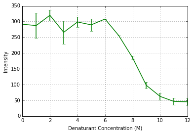

```python
bind_mean_intens = np.mean(bind_data_intens,0)
bind_std_intens = np.std(bind_data_intens,0)

plt.xlabel('Denaturant Concentration (M)')
plt.ylabel('Intensity')
plt.errorbar(bind_data_concs,bind_mean_intens, yerr=bind_std_intens, c='g');
```

In lecture notes intensity drops for all concentrations of Urea?

Fraction of protein in unfolded state; $$F_u = 1 - \frac{I - I_u}{I_n - I_u}$$

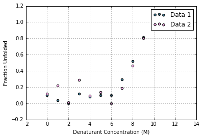

```python
F_us = []
for intens in bind_data_intens:
    F_us.append(1 - ((intens-np.min(intens))/(np.max(intens)-np.min(intens))))
for i, F_u in enumerate(F_us):
    plt.scatter(bind_data_concs, F_u, c=np.random.rand(3,1), label='Data {0}'.format(i+1))

plt.xlabel('Denaturant Concentration (M)')
plt.ylabel('Fraction Unfolded')
plt.legend();
```

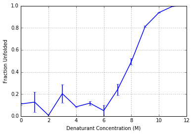

```python
bind_mean_F_u = np.mean(F_us,0)
bind_std_F_u = np.std(F_us,0)

plt.errorbar(bind_data_concs,bind_mean_F_u, yerr=bind_std_F_u, c='b')
plt.xlabel('Denaturant Concentration (M)')
plt.ylabel('Fraction Unfolded');
```

Fraction of protein in folded state; $$F_N = 1 - F_u$$

Free energy becomes; $$\Delta G = -RTln\frac{F_u}{F_n}$$

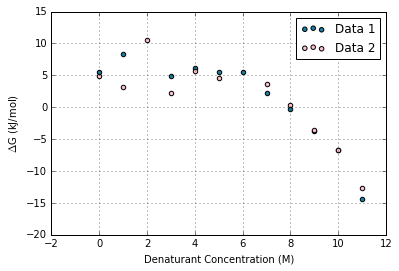

```python
R = 8.314
T = 298
delta_Gs = []
for F_u in F_us:
    F_N = 1 - F_u
    delta_G = - R*T * np.log(F_u / F_N)
    delta_G = delta_G / 1000. # convert to kJ/mol
    delta_Gs.append(delta_G)
for i, delta_G in enumerate(delta_Gs):
    plt.scatter(bind_data_concs, delta_G, c=np.random.rand(3,1), label='Data {0}'.format(i+1))
plt.xlabel('Denaturant Concentration (M)')
plt.ylabel('$\Delta$G (kJ/mol)')
plt.legend();
```

Fit a polynomial `p(x) = p[0] * x**deg + ... + p[deg]` of degree `deg` to points `(x, y)`. Returns a vector of coefficients `p` that minimises the squared error.

```python
mean_dG = np.mean(delta_Gs,0)
std_dG = np.std(delta_Gs,0)
```

By potting free energy as a function of denaturant concentration, you can to 0 M to determine free energy of unfolding; $$\Delta G = \Delta G_u^{H_2O} - m_u[Denaturant]$$

```
Free Energy of Unfolding; 25.891 kJ/mol
```

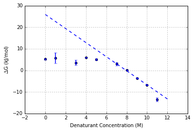

```python
e_pts = [7,8,9,10]
a, b = np.polyfit(bind_data_concs[e_pts],mean_dG[e_pts],1)
plt.scatter(bind_data_concs,mean_dG)
plt.errorbar(bind_data_concs,mean_dG,yerr=std_dG,linestyle='')
plt.plot(bind_data_concs,b+a*bind_data_concs, 'b--')
plt.xlabel('Denaturant Concentration (M)')
plt.ylabel('$\Delta$G (kJ/mol)')
print 'Free Energy of Unfolding; {0} kJ/mol'.format(round(b,3))
```